# Human activity prediction from wearable sensor data

Michael Catalano

Monday, July 20, 2015

### Summary

A classification model was applied to data generated from wearable fitness devices with the aim of predicting a specific human activity class based on corresponding sensor data. The dataset ‘pml-training.csv’ contains 19622 observations of 160 variables, most of which are accelerometer output. The ‘classe’ variable contains the five activity classes A, B, C, D and E, which correspond uniquely to one of the following activities: sitting down, standing up, standing, walking, or sitting. The origninal data can be viewed here: http://groupware.les.inf.puc-rio.br/har. After cleaning the data by removing sparse columns and non-predictor features, variable importance was evaluated by a near-zero-variance test as well as scaled PCA. It was determined that PCA did not facilitate diferentiation of activity classes

### Data Preparation

The training and test data were loaded into two separate files. Looking at the training set, it was clear that mostly sparse columns were indicated by blanks in the first row of the data. Blanks were coerced to NAs and subsequently omitted by subsetting the training set. Additionally, the first 7 columns contained no accelerometer data, so they were omitted as well. The training dataset was sliced into sub-training and validation sets in a 60/40 split ratio, respectively.

```r
#Load required packages and set seed for reproducibility
library(corrplot)
library(ggplot2)
library(caret)
library(randomForest)
library(e1071)
set.seed(333)

#Store data files
big_train <- read.csv('pml-training.csv')
test_class <- read.csv('pml-testing.csv')

#Remove columns with NA or "" in 1st row
first_row <- big_train[1, ]
first_row[first_row == ""] <- NA
NA_names <- names(first_row[ ,is.na(first_row)])
new_train <- big_train[ ,!names(big_train) %in% NA_names]

#Print first 10 remaining column names
names(new_train[1:10])
```

```
##  [1] "X"                    "user_name"            "raw_timestamp_part_1"
##  [4] "raw_timestamp_part_2" "cvtd_timestamp"       "new_window"
##  [7] "num_window"           "roll_belt"            "pitch_belt"
## [10] "yaw_belt"
```

```r
#Subset data to all reasonable predictors
trimmed_train <- new_train[8:60]

#Split data into training and validation sets
part <- createDataPartition(y=trimmed_train$classe, p=0.6, list=FALSE)
training <- trimmed_train[part, ]
testing <- trimmed_train[-part, ]
```

### Feature Selection

The “near zero variance” test was performed to get an early indication of the importance of variables. As is evident below, none of the 52 variables exhibits near zero variance. Therefore, we cannot eliminate any of the variables without further exploration.

```r
#Test for near zero variance
nzv <- nearZeroVar(training, saveMetrics=TRUE)
nzv
```

```
##                      freqRatio percentUnique zeroVar   nzv
## roll_belt             1.150794    8.72112772   FALSE FALSE
## pitch_belt            1.018182   13.59544837   FALSE FALSE
## yaw_belt              1.080386   14.52955163   FALSE FALSE
## total_accel_belt      1.086938    0.24626359   FALSE FALSE
## gyros_belt_x          1.075812    1.05298913   FALSE FALSE
## gyros_belt_y          1.192039    0.56895380   FALSE FALSE
## gyros_belt_z          1.065741    1.34171196   FALSE FALSE
## accel_belt_x          1.055085    1.32472826   FALSE FALSE
## accel_belt_y          1.145766    1.12941576   FALSE FALSE
## accel_belt_z          1.119284    2.39470109   FALSE FALSE
## magnet_belt_x         1.022124    2.50509511   FALSE FALSE
## magnet_belt_y         1.019900    2.37771739   FALSE FALSE
## magnet_belt_z         1.003448    3.61752717   FALSE FALSE
## roll_arm             54.289474   19.53974185   FALSE FALSE
## pitch_arm            89.695652   22.37601902   FALSE FALSE
## yaw_arm              32.234375   21.45889946   FALSE FALSE
## total_accel_arm       1.009191    0.56046196   FALSE FALSE
## gyros_arm_x           1.006309    5.24796196   FALSE FALSE
## gyros_arm_y           1.445860    3.06555707   FALSE FALSE
## gyros_arm_z           1.111465    1.97860054   FALSE FALSE
## accel_arm_x           1.068627    6.43682065   FALSE FALSE
## accel_arm_y           1.071942    4.43274457   FALSE FALSE
## accel_arm_z           1.012346    6.47078804   FALSE FALSE
## magnet_arm_x          1.017241   11.08186141   FALSE FALSE
## magnet_arm_y          1.071429    7.20108696   FALSE FALSE
## magnet_arm_z          1.015152   10.58084239   FALSE FALSE
## roll_dumbbell         1.095890   87.69531250   FALSE FALSE
## pitch_dumbbell        2.412500   85.26664402   FALSE FALSE
## yaw_dumbbell          1.095890   86.90557065   FALSE FALSE
## total_accel_dumbbell  1.043062    0.36514946   FALSE FALSE
## gyros_dumbbell_x      1.093220    1.94463315   FALSE FALSE
## gyros_dumbbell_y      1.236311    2.26732337   FALSE FALSE
## gyros_dumbbell_z      1.085546    1.63892663   FALSE FALSE
## accel_dumbbell_x      1.025000    3.37126359   FALSE FALSE
## accel_dumbbell_y      1.027397    3.84680707   FALSE FALSE
## accel_dumbbell_z      1.116788    3.35427989   FALSE FALSE
## magnet_dumbbell_x     1.214286    8.98437500   FALSE FALSE
## magnet_dumbbell_y     1.133929    6.82744565   FALSE FALSE
## magnet_dumbbell_z     1.137255    5.51970109   FALSE FALSE
## roll_forearm         11.605000   14.89470109   FALSE FALSE
## pitch_forearm        58.000000   21.16168478   FALSE FALSE
## yaw_forearm          15.263158   14.17289402   FALSE FALSE
## total_accel_forearm   1.132296    0.56046196   FALSE FALSE
## gyros_forearm_x       1.069182    2.33525815   FALSE FALSE
## gyros_forearm_y       1.082609    6.08016304   FALSE FALSE
## gyros_forearm_z       1.065068    2.37771739   FALSE FALSE
## accel_forearm_x       1.098039    6.57269022   FALSE FALSE
## accel_forearm_y       1.000000    8.18614130   FALSE FALSE
## accel_forearm_z       1.031579    4.63654891   FALSE FALSE
## magnet_forearm_x      1.061224   11.99048913   FALSE FALSE
## magnet_forearm_y      1.142857   15.31929348   FALSE FALSE
## magnet_forearm_z      1.000000   13.37466033   FALSE FALSE
## classe                1.469065    0.04245924   FALSE FALSE
```

```r
#PCA on training set minus classe variable
princomp <- prcomp(training[ ,1:52], scale=TRUE)

#Summary shows 80% of variance captured by 12 PCs
summary(princomp)
```

```
## Importance of components:
##                           PC1    PC2    PC3     PC4     PC5     PC6
## Standard deviation     2.8903 2.8382 2.1621 2.09968 1.90962 1.73795
## Proportion of Variance 0.1606 0.1549 0.0899 0.08478 0.07013 0.05809
## Cumulative Proportion  0.1606 0.3155 0.4054 0.49023 0.56036 0.61844
##                            PC7    PC8     PC9   PC10    PC11    PC12
## Standard deviation     1.49209 1.4350 1.31411 1.2301 1.17564 1.05276
## Proportion of Variance 0.04281 0.0396 0.03321 0.0291 0.02658 0.02131
## Cumulative Proportion  0.66126 0.7009 0.73407 0.7632 0.78975 0.81106
##                           PC13   PC14    PC15    PC16    PC17    PC18
## Standard deviation     1.00101 0.9458 0.90746 0.88270 0.82123 0.74169
## Proportion of Variance 0.01927 0.0172 0.01584 0.01498 0.01297 0.01058
## Cumulative Proportion  0.83033 0.8475 0.86337 0.87835 0.89132 0.90190
##                          PC19    PC20    PC21    PC22    PC23    PC24
## Standard deviation     0.7138 0.69626 0.64171 0.62673 0.60267 0.57948
## Proportion of Variance 0.0098 0.00932 0.00792 0.00755 0.00698 0.00646
## Cumulative Proportion  0.9117 0.92102 0.92894 0.93650 0.94348 0.94994
##                           PC25    PC26    PC27    PC28    PC29    PC30
## Standard deviation     0.55260 0.54047 0.50008 0.48290 0.44912 0.43352
## Proportion of Variance 0.00587 0.00562 0.00481 0.00448 0.00388 0.00361
## Cumulative Proportion  0.95581 0.96143 0.96624 0.97072 0.97460 0.97821
##                           PC31    PC32    PC33    PC34    PC35   PC36
## Standard deviation     0.37749 0.36166 0.34304 0.33390 0.30073 0.2793
## Proportion of Variance 0.00274 0.00252 0.00226 0.00214 0.00174 0.0015
## Cumulative Proportion  0.98096 0.98347 0.98573 0.98788 0.98962 0.9911
##                           PC37    PC38    PC39    PC40    PC41    PC42
## Standard deviation     0.25338 0.23447 0.23064 0.20093 0.19273 0.18378
## Proportion of Variance 0.00123 0.00106 0.00102 0.00078 0.00071 0.00065
## Cumulative Proportion  0.99235 0.99341 0.99443 0.99521 0.99592 0.99657
##                           PC43    PC44    PC45    PC46   PC47    PC48
## Standard deviation     0.17937 0.16465 0.16442 0.15308 0.1439 0.13664
## Proportion of Variance 0.00062 0.00052 0.00052 0.00045 0.0004 0.00036
## Cumulative Proportion  0.99719 0.99771 0.99823 0.99868 0.9991 0.99944
##                           PC49    PC50    PC51    PC52
## Standard deviation     0.11376 0.09029 0.07697 0.04602
## Proportion of Variance 0.00025 0.00016 0.00011 0.00004
## Cumulative Proportion  0.99969 0.99985 0.99996 1.00000
```

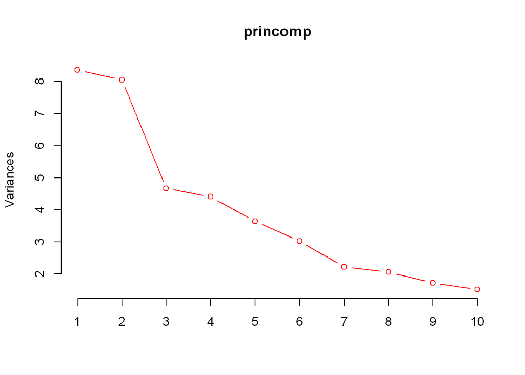

```r
#Plot variances for each component
screeplot(princomp, type='lines', col=2)
```

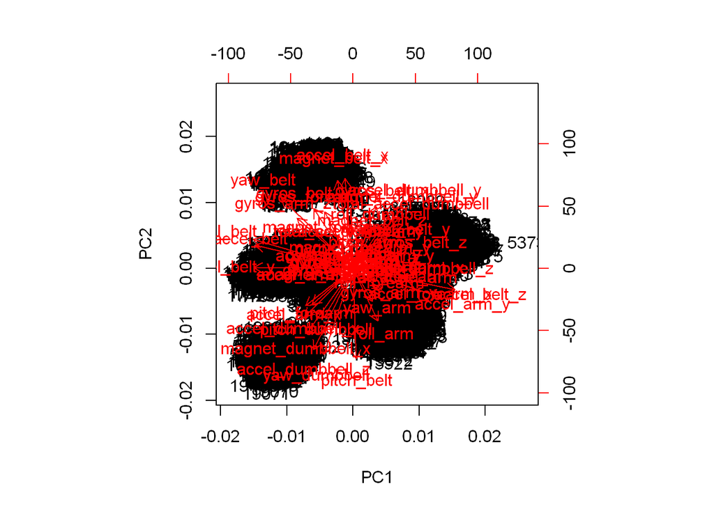

```r
#Biplot shows observation scores (points) and feature loadings (arrows)
biplot(princomp)
```

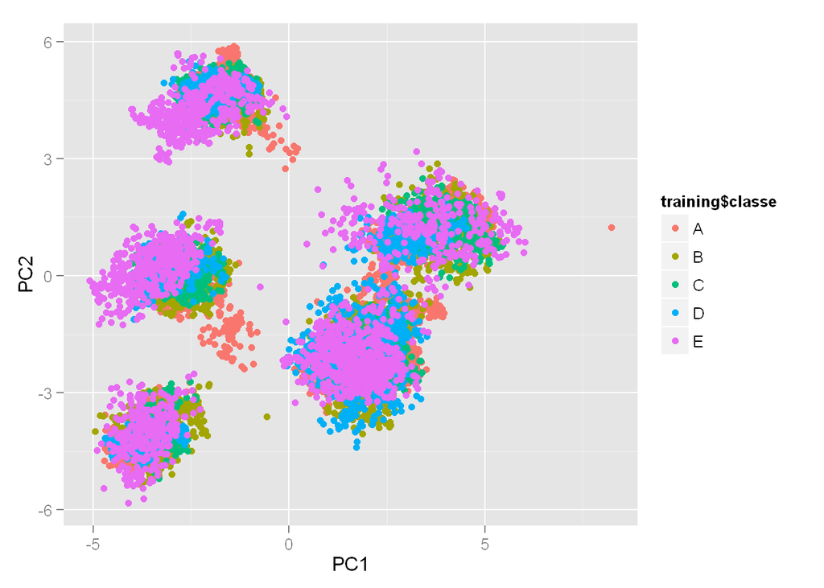

```r
#Plot PC1 vs PC2 colored by activity class.
pcp <- qplot(x=princomp$x[ ,1],
             y=princomp$x[ ,2],
             color=training$classe,
             xlab='PC1',
             ylab='PC2')
pcp
```

### Model Training

Training a random forest model on the data allows both evaluation of feature importance and estimation of out-of-bag (OOB) error rate. Additionally, there is no need for cross validation when using an RF model since each tree in the forest is constructed from a different bootstrapped sample of the original data. The model below was limited to 50 trees to reduced processing time. Even with a small number of trees, the OOB error rate is estimated to be 1.2%. A feature plot of the four most important features (based on the Gini index) shows relationships between the features that are most valuable in creating decision splits in the model. It appears that the data with respect to these variables still have considerable overlap, but presumably less than features of lower importance.

```r
#Train a random forest model on training data
rf.mod <- randomForest(classe ~.,
                       data=training,
                       type='class',
                       importance=TRUE,
                       ntree=50)
rf.mod
```

```
##
## Call:
##  randomForest(formula = classe ~ ., data = training, type = "class",      importance = TRUE, ntree = 50)
##                Type of random forest: classification
##                      Number of trees: 50
## No. of variables tried at each split: 7
##
##         OOB estimate of  error rate: 1.15%
## Confusion matrix:
##      A    B    C    D    E class.error
## A 3342    5    1    0    0 0.001792115
## B   27 2236   15    0    1 0.018867925
## C    0   21 2026    6    1 0.013631938
## D    0    1   37 1888    4 0.021761658
## E    0    1    3   12 2149 0.007390300
```

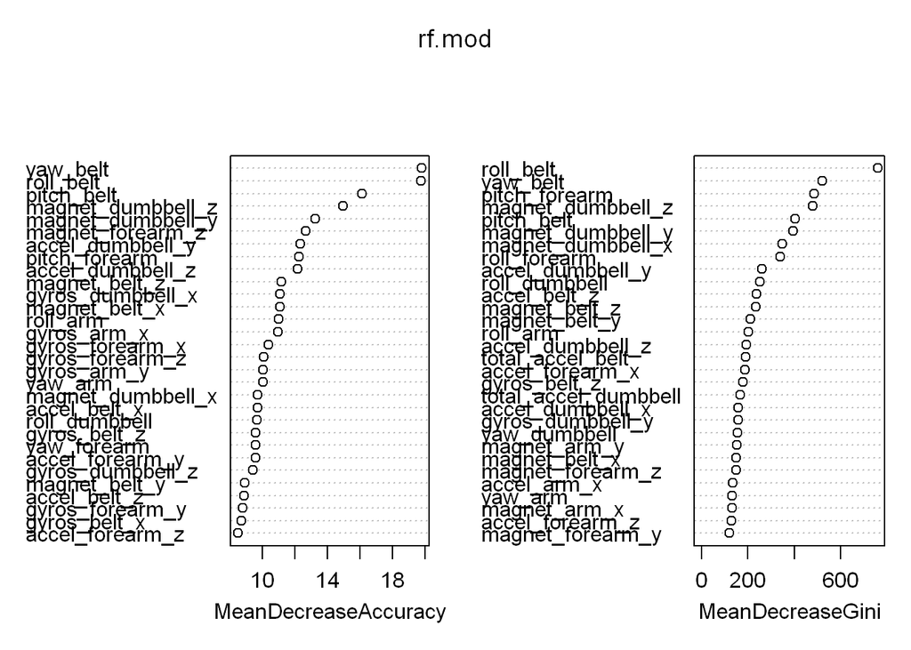

```r
#Examine importance of variables
varImpPlot(rf.mod)
```

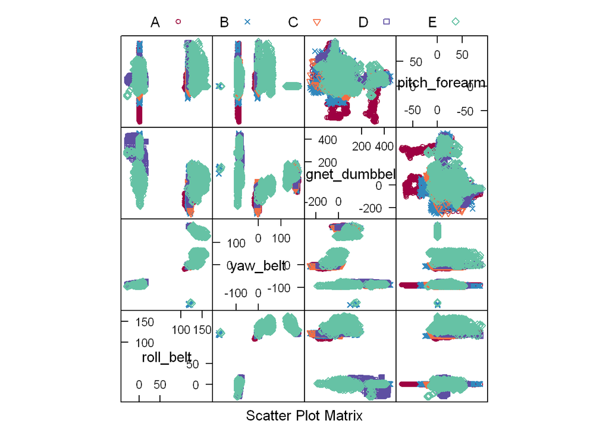

```r
#Visualize important variables with feature plot
trellis.par.set(caretTheme())
fp <- featurePlot(x=training[ ,c(1,3,39,41)],
                  y=training$classe,
                  plot='pairs',
                  auto.key = list(columns = 5),)
fp
```

### Prediction

The random forest model was used to predict class values in the testing set, and the accuracy of prediction was evaluated by constructing a confusion matrix. The out of sample error was calculated to be 0.8%, which is less than the internally estimated OOB error in the RF model (1.2%). With the model returning >99% accuracy on external data, the model was then applied to the un-tampered raw test set to generate a vector of predicted activity classes.

```r
#Predict outcomes on testing set using RF model
rf.pred <- predict(rf.mod, newdata=testing)

#Evaluate model accuracy with confusion matrix
rf.cm <- confusionMatrix(rf.pred, testing$classe)
rf.cm
```

```
## Confusion Matrix and Statistics
##
##           Reference
## Prediction    A    B    C    D    E
##          A 2229   11    0    0    0
##          B    2 1505   20    0    1
##          C    1    2 1345   20    0
##          D    0    0    3 1266    7
##          E    0    0    0    0 1434
##
## Overall Statistics
##
##                Accuracy : 0.9915
##                  95% CI : (0.9892, 0.9934)
##     No Information Rate : 0.2845
##     P-Value [Acc > NIR] : < 2.2e-16
##
##                   Kappa : 0.9892
##  Mcnemar's Test P-Value : NA
##
## Statistics by Class:
##
##                      Class: A Class: B Class: C Class: D Class: E
## Sensitivity            0.9987   0.9914   0.9832   0.9844   0.9945
## Specificity            0.9980   0.9964   0.9964   0.9985   1.0000
## Pos Pred Value         0.9951   0.9849   0.9832   0.9922   1.0000
## Neg Pred Value         0.9995   0.9979   0.9964   0.9970   0.9988
## Prevalence             0.2845   0.1935   0.1744   0.1639   0.1838
## Detection Rate         0.2841   0.1918   0.1714   0.1614   0.1828
## Detection Prevalence   0.2855   0.1947   0.1744   0.1626   0.1828
## Balanced Accuracy      0.9983   0.9939   0.9898   0.9915   0.9972
```

```r
#Predict outcomes for the orignal test set file
rf.test <- predict(rf.mod, newdata=test_class)

#Store predicted values as a vector of answers
answers <- as.vector(rf.test)
answers
```

```
##  [1] "B" "A" "B" "A" "A" "E" "D" "B" "A" "A" "B" "C" "B" "A" "E" "E" "A"
## [18] "B" "B" "B"
```

```r
#Write predicted values to submission text files
write_files <- function(x){
    n = length(x)
    for(i in 1:n){
        filename = paste0("problem_id_",i,".txt")
        write.table(x[i], file=filename, quote=FALSE, row.names=FALSE, col.names=FALSE)
    }
}

write_files(answers)
```